# Behind every data point lies a child, a life, and a policy choice

Author

Vigneshwaran

Published

April 28, 2025

# Behind every data point lies a child, a life, and a policy choice.

We begin our story with a world map of military spending, revealing how nations — including those with fragile economies — allocate significant resources to defense. This sets the stage for understanding how resource prioritization can shape social outcomes.

To explore the broader link between economic well-being and human outcomes, we zoom out with a scatterplot of GDP per capita vs. life expectancy. The trend is unmistakable: wealthier countries enjoy longer lives. But the scattered points tell another truth — not all countries convert wealth into well-being equally.

*In sum, these graphs collectively urge us to ask: how are national priorities shaping the lives — and deaths — of the most vulnerable?*

```python
from google.colab import files
uploaded = files.upload()
```

Upload widget is only available when the cell has been executed in the current browser session. Please rerun this cell to enable.

```
Saving unicef_metadata (4).csv to unicef_metadata (4).csv
Saving unicef_indicator_2 (3).csv to unicef_indicator_2 (3).csv
Saving unicef_indicator_1 (3).csv to unicef_indicator_1 (3).csv
```

### World Map of Military Spending

A choropleth map displays military spending by country, shading each nation according to the scale of its expenditure as a percentage of GDP. Darker shades indicate higher spending levels.

We observe that military spending varies greatly, with some lower-income countries investing disproportionately high percentages of their GDP, potentially diverting funds from essential social services.

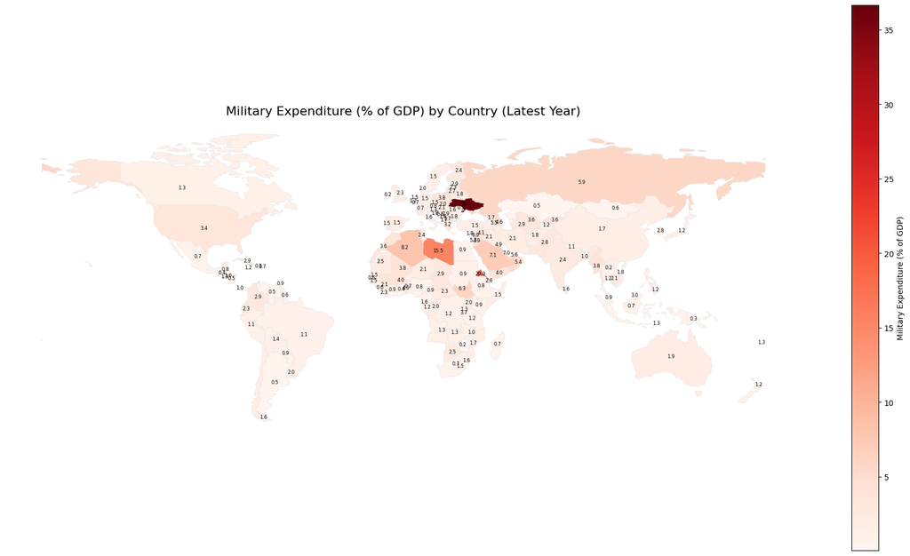

```python
!pip install geopandas

import geopandas as gpd
import pandas as pd
import matplotlib.pyplot as plt
import requests, zipfile, io, os

# Set URL and headers (simulate a browser request)
url = "https://www.naturalearthdata.com/http//www.naturalearthdata.com/download/110m/cultural/ne_110m_admin_0_countries.zip"
fixed_url = "https://naturalearth.s3.amazonaws.com/110m_cultural/ne_110m_admin_0_countries.zip"
headers = {'User-Agent': 'Mozilla/5.0'}

# Request with header to avoid 406 error
response = requests.get(fixed_url, headers=headers)
response.raise_for_status()

# Extract shapefile
z = zipfile.ZipFile(io.BytesIO(response.content))
z.extractall("ne_110m_admin_0_countries")

# Load shapefile
world = gpd.read_file("ne_110m_admin_0_countries/ne_110m_admin_0_countries.shp")

# Load military data
metadata = pd.read_csv('unicef_metadata (4).csv')
military_df = metadata.dropna(subset=["Military expenditure (% of GDP)"])
latest_years = military_df.groupby("country")["year"].idxmax()
military_latest = military_df.loc[latest_years]

# Merge
merged = world.merge(military_latest, left_on="ISO_A3", right_on="alpha_3_code")

# Plot
fig, ax = plt.subplots(figsize=(18, 10))
merged.plot(column="Military expenditure (% of GDP)",
            cmap="Reds",
            linewidth=0.5,
            edgecolor="0.9",
            legend=True,
            legend_kwds={'label': "Military Expenditure (% of GDP)"},
            ax=ax,
            missing_kwds={"color": "lightgrey", "label": "No data"})

# Annotate with spending values
for idx, row in merged.iterrows():
    point = row["geometry"].representative_point()
    val = row["Military expenditure (% of GDP)"]
    ax.text(point.x, point.y, f"{val:.1f}", fontsize=6, ha='center', color='black')

ax.set_title("Military Expenditure (% of GDP) by Country (Latest Year)", fontsize=16)
ax.axis('off')
plt.tight_layout()
plt.show()
```

### Bar Chart of Infant Mortality (1–59 Months)

A horizontal bar chart shows the 10 countries with the highest infant mortality rates for children aged 1 to 59 months. The countries are sorted in descending order by mortality rate.

Most of the top 10 countries are low-income or conflict-affected, suggesting a link between poverty, weak health systems, and child survival.

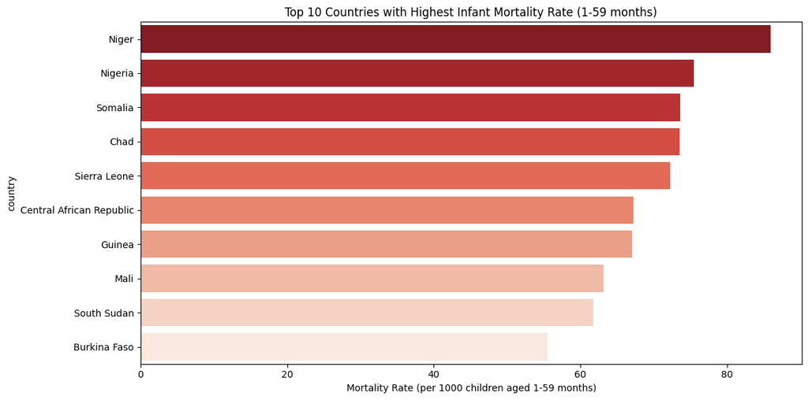

```python
import pandas as pd
import seaborn as sns
import matplotlib.pyplot as plt

# Load the file (use your uploaded path in Colab)
indicator1 = pd.read_csv("unicef_indicator_1 (3).csv")

# Filter for infant mortality (1-59 months)
mortality = indicator1[indicator1['indicator'] == 'Mortality rate 1-59 months']

# Get latest data per country
latest_mortality = mortality.sort_values('time_period').drop_duplicates('country', keep='last')

# Top 10 countries by mortality
top10_mortality = latest_mortality.sort_values('obs_value', ascending=False).head(10)

# Plot
plt.figure(figsize=(12,6))
sns.barplot(data=top10_mortality, x='obs_value', y='country', palette='Reds_r')
plt.xlabel("Mortality Rate (per 1000 children aged 1-59 months)")
plt.title("Top 10 Countries with Highest Infant Mortality Rate (1-59 months)")
plt.tight_layout()
plt.show()
```

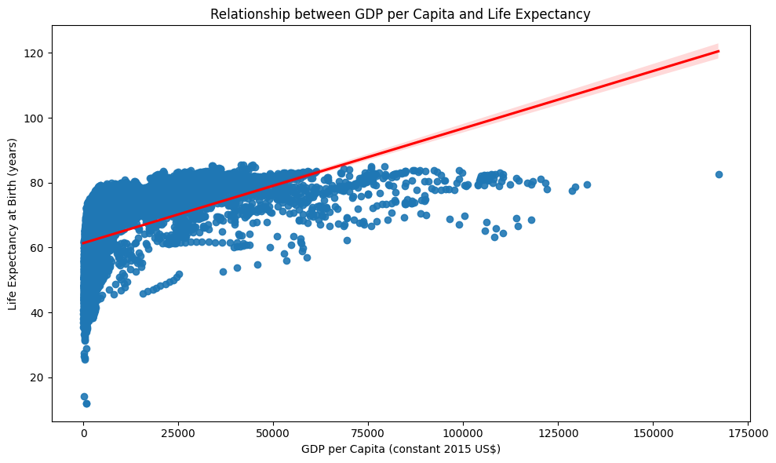

```python
import pandas as pd
import seaborn as sns
import matplotlib.pyplot as plt

# Load metadata
metadata = pd.read_csv("unicef_metadata (4).csv")

# Use correct column names
data = metadata.dropna(subset=["Life expectancy at birth, total (years)", "GDP per capita (constant 2015 US$)"])

# Plot scatter with regression line
plt.figure(figsize=(10, 6))
sns.regplot(
    data=data,
    x="GDP per capita (constant 2015 US$)",
    y="Life expectancy at birth, total (years)",
    scatter_kws={'alpha': 0.9},
    line_kws={'color': 'red'}
)
plt.xlabel("GDP per Capita (constant 2015 US$)")
plt.ylabel("Life Expectancy at Birth (years)")
plt.title("Relationship between GDP per Capita and Life Expectancy")
plt.tight_layout()
plt.show()
```

### Scatter Plot: GDP per Capita vs. Life Expectancy

There is a clear positive correlation: countries with higher GDP per capita tend to have higher life expectancy. However, a few outliers indicate that income alone does not guarantee longevity — health investments matter.

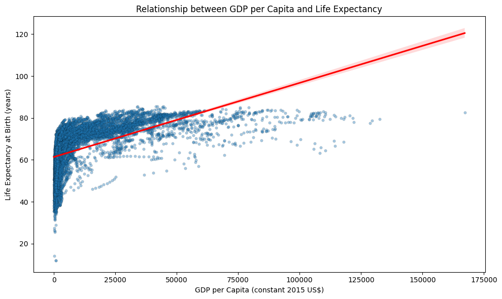

```python
import pandas as pd
import seaborn as sns
import matplotlib.pyplot as plt

# Load the metadata CSV
metadata = pd.read_csv("unicef_metadata (4).csv")

# Drop rows with missing values for relevant indicators
data = metadata.dropna(subset=["Life expectancy at birth, total (years)", "GDP per capita (constant 2015 US$)"])

# Create scatter plot with regression line
plt.figure(figsize=(10, 6))
sns.regplot(
    data=data,
    x="GDP per capita (constant 2015 US$)",
    y="Life expectancy at birth, total (years)",
    scatter_kws={'alpha': 0.4, 's': 15, 'edgecolor': 'black', 'linewidths': 0.2},
    line_kws={'color': 'red'}
)

plt.xlabel("GDP per Capita (constant 2015 US$)")
plt.ylabel("Life Expectancy at Birth (years)")
plt.title("Relationship between GDP per Capita and Life Expectancy")
plt.tight_layout()
plt.show()
```

### Time Series Chart of Life Expectency

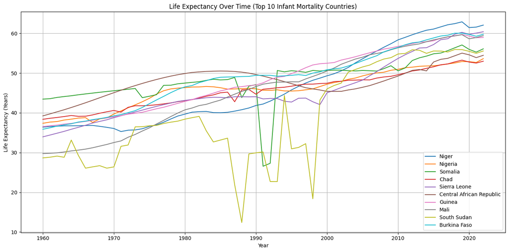

```python
# Get list of top 10 countries
top10_countries = top10_mortality["country"].unique()

# Filter metadata for those countries
life_expectancy = metadata[metadata["country"].isin(top10_countries)]

# Plot time-series
plt.figure(figsize=(14, 7))
for country in top10_countries:
    country_data = life_expectancy[life_expectancy["country"] == country]
    plt.plot(
        country_data["year"],
        country_data["Life expectancy at birth, total (years)"],
        label=country
    )

plt.title("Life Expectancy Over Time (Top 10 Infant Mortality Countries)")
plt.xlabel("Year")
plt.ylabel("Life Expectancy (Years)")
plt.legend()
plt.grid(True)
plt.tight_layout()
plt.show()
```